# Task1

Author

Slavka

Published

October 1, 2024

# 11Atomic Types

Question description

Create the following variables related to your chosen object: - 4 numeric values (e.g., population, temperature, size, rating)  
- 3 integer values (e.g., number of moons, buildings, inhabitants)  
- 2 logical values (e.g., has_water, is_inhabited)  
- 3 character values (e.g., name, region, category)

```r
# code for solving task
#integer
population <- 81702
area <- 70 #square kilometers
number_of_districts <- 4

#charakter
city_name <- "Presov"
city_old_name <- "Eperjes"
region <- "Presov Region"

#numeric
average_temperature <- 9.3
city_budget_million <- 145.6
unemployment_rate <- 6.2
population_density <- 1167.17

#logical
has_university <- TRUE
is_capital <- FALSE
```

# 12Vectors

Create three different vectors:

1. **Numeric vector** combining all your numeric and integer variables.  
   *(Use `c()`.)*
2. **Sequence vector** from any number between 10–50 to 100, Choose step between 2 and 10.  
   *(Use `seq()` or `:`.)*
3. **Logical vector** of length 10 with random `TRUE`/`FALSE` values using `sample()`.

```r
#_code for solving task
# 1. Numeric vector
numeric_vector <- c(population, area, number_of_districts, average_temperature,
                    city_budget_million, unemployment_rate, population_density)
numeric_vector
```

```
[1] 81702.00    70.00     4.00     9.30   145.60     6.20  1167.17
```

```r
# 2. Sequence vector
sequence_vector <- seq(20, 100, by = 10)
sequence_vector
```

```
[1]  20  30  40  50  60  70  80  90 100
```

```r
# 3. Logical vector
logical_vec <- sample(c(TRUE, FALSE), size = 10, replace = TRUE)
logical_vec
```

```
 [1] FALSE FALSE  TRUE  TRUE FALSE  TRUE FALSE  TRUE FALSE  TRUE
```

### 13MATRIX

Create a **3×3 matrix** with random numbers between **-50 and 50**  
(using `sample()` or `runif()`), and name its **rows and columns** according to your theme.

```r
#_code for solving task
set.seed(123)  # so results stay the same each time
my_matrix <- matrix(sample(-50:50, 9, replace = TRUE), nrow = 3, ncol = 3)

# Name rows and columns according to your theme
rownames(my_matrix) <- c("Center", "North", "South")
colnames(my_matrix) <- c("Economy", "Education", "Transport")

my_matrix
```

```
       Economy Education Transport
Center     -20       -37        -1
North       28        16        -8
South        0        -9        50
```

```r
# Row and column averages
rowMeans(my_matrix)
```

```
   Center     North     South
-19.33333  12.00000  13.66667
```

```r
colMeans(my_matrix)
```

```
   Economy  Education  Transport
  2.666667 -10.000000  13.666667
```

# 14LIST

Create a **list** that combines all your previous objects:  
atomic variables, vectors, and matrix. Add one extra element — a short **description** of your universe as a string.

```r
#_code for solving task
presov_list <- list(
  city_name = city_name,
  region = region,
  population = population,
  numeric_vector = numeric_vector,
  sequence_vector = sequence_vector,
  logical_vec = logical_vec,
  matrix = my_matrix,
  description = "This is the data universe of Presov — a Slovak city full of culture, students, and history!"
)

# View the list
presov_list
```

```
$city_name
[1] "Presov"

$region
[1] "Presov Region"

$population
[1] 81702

$numeric_vector
[1] 81702.00    70.00     4.00     9.30   145.60     6.20  1167.17

$sequence_vector
[1]  20  30  40  50  60  70  80  90 100

$logical_vec
 [1] FALSE FALSE  TRUE  TRUE FALSE  TRUE FALSE  TRUE FALSE  TRUE

$matrix
       Economy Education Transport
Center     -20       -37        -1
North       28        16        -8
South        0        -9        50

$description
[1] "This is the data universe of Presov — a Slovak city full of culture, students, and history!"
```

# 15Factor

Create a **factor variable** representing categories within your universe, e.g.:

- `"low"`, `"medium"`, `"high"`
- `"infant"`, `"child"`, `"adult"`
- `"poor"`, `"average"`, `"rich"`

Make sure you have **at least 5 observations** total.  
Then use `table()` to show how many objects fall into each category.

```r
#code_for solving task

city_size <- factor(c("medium", "large", "large", "medium", "small", "large", "medium"))

# Display counts
table(city_size)
```

```
city_size
 large medium  small
     3      3      1
```

# 16Data Frame

Create a **data frame** related to your object that includes:

1. **5–8 observations** (rows)
2. **At least 3 columns** of different data types  
   (e.g., name, numeric value, logical flag, category)

```r
#_code for solving task
presov_df <- data.frame(
  District = c("Solivar", "Sekcov", "Trojica", "Calvary", "Delna"),
  Population = c(14000, 21000, 13000, 18000, 15702),
  Has_School = c(TRUE, TRUE, TRUE, FALSE, TRUE),
  Area_km2 = c(12.3, 20.1, 9.4, 15.8, 12.4),
  Category = factor(c("residential", "residential", "historic", "suburban", "mixed"))
)

# Rename columns (optional)
colnames(presov_df) <- c("District_Name", "Population", "Has_School", "Area_km2", "Category")

# Structure and summary
str(presov_df)
```

```
'data.frame':   5 obs. of  5 variables:
 $ District_Name: chr  "Solivar" "Sekcov" "Trojica" "Calvary" ...
 $ Population   : num  14000 21000 13000 18000 15702
 $ Has_School   : logi  TRUE TRUE TRUE FALSE TRUE
 $ Area_km2     : num  12.3 20.1 9.4 15.8 12.4
 $ Category     : Factor w/ 4 levels "historic","mixed",..: 3 3 1 4 2
```

```r
summary(presov_df)
```

```
 District_Name        Population    Has_School         Area_km2
 Length:5           Min.   :13000   Mode :logical   Min.   : 9.4
 Class :character   1st Qu.:14000   FALSE:1         1st Qu.:12.3
 Mode  :character   Median :15702   TRUE :4         Median :12.4
                    Mean   :16340                   Mean   :14.0
                    3rd Qu.:18000                   3rd Qu.:15.8
                    Max.   :21000                   Max.   :20.1
        Category
 historic   :1
 mixed      :1
 residential:2
 suburban   :1
```

```r
# Add new derived column: population density per district
presov_df$Density <- presov_df$Population / presov_df$Area_km2

# Show final data frame
presov_df
```

```
  District_Name Population Has_School Area_km2    Category  Density
1       Solivar      14000       TRUE     12.3 residential 1138.211
2        Sekcov      21000       TRUE     20.1 residential 1044.776
3       Trojica      13000       TRUE      9.4    historic 1382.979
4       Calvary      18000      FALSE     15.8    suburban 1139.241
5         Delna      15702       TRUE     12.4       mixed 1266.290
```

#Task 2 Yaroslava Bohovych

## Task 2: Subsetting & Missing Data in Your Mini-Universe

### 2.1. Querying Vectors

Let’s start with the vectors you created in **Task 1**.

#2.1.1. From your **Sequence vector** (the one with all your numbers):

- Select and print the 3rd element.
- Select and print elements 2 through 5.
- Select and print all values that are greater than 20 (or another number that makes sense for your data).

```r
# Select and print the 3rd element
sequence_vector[3]
```

```
[1] 40
```

```r
# Select and print elements 2 through 5
sequence_vector[2:5]
```

```
[1] 30 40 50 60
```

```r
# Select and print all values greater than 50
sequence_vector[sequence_vector > 50]
```

```
[1]  60  70  80  90 100
```

#2.1.2. From your **Logical vector**:

- Select and print only the TRUE values. (Hint: `your_vector[your_vector]`).
- Use `which()` to get the indices (positions) of all the `TRUE` values.

```r
# Select and print only the TRUE values
logical_vec[logical_vec]
```

```
[1] TRUE TRUE TRUE TRUE TRUE
```

```r
# Get indices (positions) of all TRUE values
which(logical_vec)
```

```
[1]  3  4  6  8 10
```

### 2.2. Querying Your “Universe” List

Use your main list from **Task 1**.

- Access and print the **description** string using the `$` operator
- Access and print your **3x3 matrix** using double brackets `[[ ]]`.
- Access and print the **second element** from your **vector element** within the list. (This will be a “list-within-a-list” access).

```r
# Access and print the description string using $
presov_list$description
```

```
[1] "This is the data universe of Presov — a Slovak city full of culture, students, and history!"
```

```r
# Access and print your 3x3 matrix using double brackets [[ ]]
presov_list[[7]]   # or presov_list$matrix
```

```
       Economy Education Transport
Center     -20       -37        -1
North       28        16        -8
South        0        -9        50
```

```r
# Access and print the 2nd element from your numeric vector inside the list
presov_list$numeric_vector[2]
```

```
[1] 70
```

### 2.3. Investigating Your Data Frame

Use the **data frame** you created in **Task 1**.

- Print the **first 3 rows**. (Use `head()`.)
- Print the value from the **4th row, 1st column**.
- Print only the column that contains your logical values (e.g., `is_habitable`) as a vector.

**Logical Subsetting**: Create a new data frame `df_subset` that contains only the rows that meet a specific logical condition.

- Example: `df_subset <- your_df[your_df$population > 1000, ]`

`%in%` **Subsetting**: Create a new data frame `df_subset_2` that selects rows belonging to **two specific categories** from your factor or character column.

- Example: `df_subset_2 <- your_df[your_df$region %in% c("North", "South"), ]`

```r
# Print the first 3 rows of your data frame
head(presov_df, 3)
```

```
  District_Name Population Has_School Area_km2    Category  Density
1       Solivar      14000       TRUE     12.3 residential 1138.211
2        Sekcov      21000       TRUE     20.1 residential 1044.776
3       Trojica      13000       TRUE      9.4    historic 1382.979
```

```r
# Print the value from the 4th row, 1st column
presov_df[4, 1]
```

```
[1] "Calvary"
```

```r
# Print only the logical column (Has_School)
presov_df$Has_School
```

```
[1]  TRUE  TRUE  TRUE FALSE  TRUE
```

```r
# Logical Subsetting: keep only districts with population > 15000
presov_subset <- presov_df[presov_df$Population > 15000, ]
presov_subset
```

```
  District_Name Population Has_School Area_km2    Category  Density
2        Sekcov      21000       TRUE     20.1 residential 1044.776
4       Calvary      18000      FALSE     15.8    suburban 1139.241
5         Delna      15702       TRUE     12.4       mixed 1266.290
```

```r
# %in% Subsetting: select districts with "residential" or "historic" category
presov_subset_2 <- presov_df[presov_df$Category %in% c("residential", "historic"), ]
presov_subset_2
```

```
  District_Name Population Has_School Area_km2    Category  Density
1       Solivar      14000       TRUE     12.3 residential 1138.211
2        Sekcov      21000       TRUE     20.1 residential 1044.776
3       Trojica      13000       TRUE      9.4    historic 1382.979
```

### 2.4. Handling “Corrupted” Data (`NA`)

Create a copy of your original data frame (e.g., `df_corrupted <- your_df`).

**Introduce 3 `NA`s** into your df_corrupted at specific locations.

- Example: `df_corrupted[2, 3] <- NA`

**Find `NAs`**:

- Use `sum(is.na(df_corrupted)`) to find the **total number** of missing values.
- Use `colSums(is.na(df_corrupted))` to see how many `NA`s are in **each column**.

**Calculate with `NA`s**:

- Calculate the `mean()` of the numeric column where you added an `NA`.

**Filter `NA`s**:

- Use `na.omit(df_corrupted)` to create a new, “clean” data frame that contains only the complete rows.

```r
# Create a copy of your original data frame
presov_corrupted <- presov_df

# Introduce 3 NA values at specific locations
presov_corrupted[2, 2] <- NA    # Missing population for Sekcov
presov_corrupted[4, 3] <- NA    # Missing Has_School for Calvary
presov_corrupted[5, 5] <- NA    # Missing Category for Delna

# Find total number of missing values
sum(is.na(presov_corrupted))
```

```
[1] 3
```

```r
# Find how many NAs per column
colSums(is.na(presov_corrupted))
```

```
District_Name    Population    Has_School      Area_km2      Category
            0             1             1             0             1
      Density
            0
```

```r
# Calculate mean of Population (will return NA)
mean(presov_corrupted$Population)
```

```
[1] NA
```

```r
# Calculate mean ignoring NAs
mean(presov_corrupted$Population, na.rm = TRUE)
```

```
[1] 15175.5
```

```r
# Remove rows with NAs
presov_clean <- na.omit(presov_corrupted)
presov_clean
```

```
  District_Name Population Has_School Area_km2    Category  Density
1       Solivar      14000       TRUE     12.3 residential 1138.211
3       Trojica      13000       TRUE      9.4    historic 1382.979
```

### 2.5. Bonus Challenge: `which()`

Use `which.max()` or `which.min()` to find the **row number** (index) of the observation with the highest or lowest value in one of your numeric columns.

```r
# Find index of the row with the highest Population
highest_pop_index <- which.max(presov_df$Population)

# Print that row
presov_df[highest_pop_index, ]
```

```
  District_Name Population Has_School Area_km2    Category  Density
2        Sekcov      21000       TRUE     20.1 residential 1044.776
```

```r
# Find index of the row with the smallest Area_km2
smallest_area_index <- which.min(presov_df$Area_km2)

# Print that row
presov_df[smallest_area_index, ]
```

```
  District_Name Population Has_School Area_km2 Category  Density
3       Trojica      13000       TRUE      9.4 historic 1382.979
```

## Task 3: Expanding Your Universe

Your “mini-universe” in Tasks 1 & 2 was a simulation. Now, it’s time to connect it to the real world.

Your mission is to find a real dataset that expands on your theme, import it into R, and explore it using the dplyr package.

### 3.1. The Quest: Find Your Data

Find one simple, real-world dataset that fits your theme.

- **Where to look:** Kaggle, TidyTuesday, data.gov, or other public data portals.
- **Format:** Any format you are able to read. For simplicity it is proposed to use **textual (csv, txt)** or **Excel** format.
- **Requirements:**
  - At least 50 rows.
  - At least 4 columns.
  - A mix of numeric and character/factor data.
- **Action:**
  1. Download the data file and place it in your R project directory.
  2. In your task file add a line with the link to the data source (e.g., Data from: https://…).

  ### 3.2. The Import: Load Your Data
1. **Install** `tidyverse`: If you haven’t, run `install.packages("tidyverse")` in your console (just once).
2. **Load libraries:** At the top of your script, add `library(dplyr)` and `library(readr)` (`library(readxl)` in case of Excel file format).
3. **Read the data:** Use `read_csv()` (or `read_excel()`) to load your dataset into a new data frame.

```r
# Load Libraries
library(dplyr)
library(readr)
# Load the dataset (make sure zoo.csv is in your project folder)
zoo_data <- read_csv("zoo.csv")
# Inspect the dataset
glimpse(zoo_data)
```

```
Rows: 101
Columns: 18
$ animal_name <chr> "aardvark", "antelope", "bass", "bear", "boar", "buffalo",…
$ hair        <dbl> 1, 1, 0, 1, 1, 1, 1, 0, 0, 1, 1, 0, 0, 0, 0, 0, 0, 1, 0, 0…
$ feathers    <dbl> 0, 0, 0, 0, 0, 0, 0, 0, 0, 0, 0, 1, 0, 0, 0, 0, 1, 0, 0, 0…
$ eggs        <dbl> 0, 0, 1, 0, 0, 0, 0, 1, 1, 0, 0, 1, 1, 1, 1, 1, 1, 0, 1, 0…
$ milk        <dbl> 1, 1, 0, 1, 1, 1, 1, 0, 0, 1, 1, 0, 0, 0, 0, 0, 0, 1, 0, 1…
$ airborne    <dbl> 0, 0, 0, 0, 0, 0, 0, 0, 0, 0, 0, 1, 0, 0, 0, 0, 1, 0, 0, 0…
$ aquatic     <dbl> 0, 0, 1, 0, 0, 0, 0, 1, 1, 0, 0, 0, 1, 0, 1, 1, 0, 0, 1, 1…
$ predator    <dbl> 1, 0, 1, 1, 1, 0, 0, 0, 1, 0, 1, 0, 1, 1, 1, 1, 1, 0, 1, 1…
$ toothed     <dbl> 1, 1, 1, 1, 1, 1, 1, 1, 1, 1, 1, 0, 1, 0, 0, 0, 0, 1, 1, 1…
$ backbone    <dbl> 1, 1, 1, 1, 1, 1, 1, 1, 1, 1, 1, 1, 1, 0, 0, 0, 1, 1, 1, 1…
$ breathes    <dbl> 1, 1, 0, 1, 1, 1, 1, 0, 0, 1, 1, 1, 0, 0, 0, 0, 1, 1, 0, 1…
$ venomous    <dbl> 0, 0, 0, 0, 0, 0, 0, 0, 0, 0, 0, 0, 0, 0, 0, 0, 0, 0, 0, 0…
$ fins        <dbl> 0, 0, 1, 0, 0, 0, 0, 1, 1, 0, 0, 0, 1, 0, 0, 0, 0, 0, 1, 1…
$ legs        <dbl> 4, 4, 0, 4, 4, 4, 4, 0, 0, 4, 4, 2, 0, 0, 4, 6, 2, 4, 0, 0…
$ tail        <dbl> 0, 1, 1, 0, 1, 1, 1, 1, 1, 0, 1, 1, 1, 0, 0, 0, 1, 1, 1, 1…
$ domestic    <dbl> 0, 0, 0, 0, 0, 0, 1, 1, 0, 1, 0, 1, 0, 0, 0, 0, 0, 0, 0, 0…
$ catsize     <dbl> 1, 1, 0, 1, 1, 1, 1, 0, 0, 0, 1, 0, 0, 0, 0, 0, 0, 1, 1, 1…
$ class_type  <dbl> 1, 1, 4, 1, 1, 1, 1, 4, 4, 1, 1, 2, 4, 7, 7, 7, 2, 1, 4, 1…
```

```r
head(zoo_data)
```

```
# A tibble: 6 × 18
  animal_name  hair feathers  eggs  milk airborne aquatic predator toothed
  <chr>       <dbl>    <dbl> <dbl> <dbl>    <dbl>   <dbl>    <dbl>   <dbl>
1 aardvark        1        0     0     1        0       0        1       1
2 antelope        1        0     0     1        0       0        0       1
3 bass            0        0     1     0        0       1        1       1
4 bear            1        0     0     1        0       0        1       1
5 boar            1        0     0     1        0       0        1       1
6 buffalo         1        0     0     1        0       0        0       1
# ℹ 9 more variables: backbone <dbl>, breathes <dbl>, venomous <dbl>,
#   fins <dbl>, legs <dbl>, tail <dbl>, domestic <dbl>, catsize <dbl>,
#   class_type <dbl>
```

```r
summary(zoo_data)
```

```
 animal_name             hair           feathers          eggs
 Length:101         Min.   :0.0000   Min.   :0.000   Min.   :0.0000
 Class :character   1st Qu.:0.0000   1st Qu.:0.000   1st Qu.:0.0000
 Mode  :character   Median :0.0000   Median :0.000   Median :1.0000
                    Mean   :0.4257   Mean   :0.198   Mean   :0.5842
                    3rd Qu.:1.0000   3rd Qu.:0.000   3rd Qu.:1.0000
                    Max.   :1.0000   Max.   :1.000   Max.   :1.0000
      milk           airborne         aquatic          predator
 Min.   :0.0000   Min.   :0.0000   Min.   :0.0000   Min.   :0.0000
 1st Qu.:0.0000   1st Qu.:0.0000   1st Qu.:0.0000   1st Qu.:0.0000
 Median :0.0000   Median :0.0000   Median :0.0000   Median :1.0000
 Mean   :0.4059   Mean   :0.2376   Mean   :0.3564   Mean   :0.5545
 3rd Qu.:1.0000   3rd Qu.:0.0000   3rd Qu.:1.0000   3rd Qu.:1.0000
 Max.   :1.0000   Max.   :1.0000   Max.   :1.0000   Max.   :1.0000
    toothed         backbone         breathes         venomous
 Min.   :0.000   Min.   :0.0000   Min.   :0.0000   Min.   :0.00000
 1st Qu.:0.000   1st Qu.:1.0000   1st Qu.:1.0000   1st Qu.:0.00000
 Median :1.000   Median :1.0000   Median :1.0000   Median :0.00000
 Mean   :0.604   Mean   :0.8218   Mean   :0.7921   Mean   :0.07921
 3rd Qu.:1.000   3rd Qu.:1.0000   3rd Qu.:1.0000   3rd Qu.:0.00000
 Max.   :1.000   Max.   :1.0000   Max.   :1.0000   Max.   :1.00000
      fins             legs            tail           domestic
 Min.   :0.0000   Min.   :0.000   Min.   :0.0000   Min.   :0.0000
 1st Qu.:0.0000   1st Qu.:2.000   1st Qu.:0.0000   1st Qu.:0.0000
 Median :0.0000   Median :4.000   Median :1.0000   Median :0.0000
 Mean   :0.1683   Mean   :2.842   Mean   :0.7426   Mean   :0.1287
 3rd Qu.:0.0000   3rd Qu.:4.000   3rd Qu.:1.0000   3rd Qu.:0.0000
 Max.   :1.0000   Max.   :8.000   Max.   :1.0000   Max.   :1.0000
    catsize         class_type
 Min.   :0.0000   Min.   :1.000
 1st Qu.:0.0000   1st Qu.:1.000
 Median :0.0000   Median :2.000
 Mean   :0.4356   Mean   :2.832
 3rd Qu.:1.0000   3rd Qu.:4.000
 Max.   :1.0000   Max.   :7.000
```

### 3.3. The Interrogation: Explore with `dplyr`

This is the core of the task. Your goal is to **ask and answer 5 interesting questions** about your new dataset.

You must write the question in plain English (as a comment), followed by the `dplyr` code that answers it.

You **must** use each of the following `dplyr` “verbs” at least once:

- `select()` - To pick specific columns.
- `filter()` - To subset rows based on a condition.
- `arrange()` - To sort your results (e.g., with desc()).
- `mutate()` - To create a new column.

`group_by()` and `summarise()` - To get summary statistics (like `mean()`, `n()`, `max()`, etc.).

**Your 5 Questions (example):**

#*Question 1: Which 10 animals have the highest number of legs?

```r
# Q1: Animals with the most legs
zoo_data %>%
  select(animal_name, legs) %>%
  arrange(desc(legs)) %>%
  head(10)
```

```
# A tibble: 10 × 2
   animal_name  legs
   <chr>       <dbl>
 1 octopus         8
 2 scorpion        8
 3 crayfish        6
 4 flea            6
 5 gnat            6
 6 honeybee        6
 7 housefly        6
 8 ladybird        6
 9 lobster         6
10 moth            6
```

#*Question 2: How many animals belong to each class type?

```r
# Q2: Count animals in each class
zoo_data %>%
  group_by(class_type) %>%
  summarise(count = n())
```

```
# A tibble: 7 × 2
  class_type count
       <dbl> <int>
1          1    41
2          2    20
3          3     5
4          4    13
5          5     4
6          6     8
7          7    10
```

#*Question 3: Which animals are both predators and airborne?

```r
# Q3: Airborne predators
zoo_data %>%
  filter(predator == 1, airborne == 1) %>%
  select(animal_name, predator, airborne)
```

```
# A tibble: 7 × 3
  animal_name predator airborne
  <chr>          <dbl>    <dbl>
1 crow               1        1
2 gull               1        1
3 hawk               1        1
4 ladybird           1        1
5 skimmer            1        1
6 skua               1        1
7 vulture            1        1
```

#*Question 4: Create a new variable: “is_mammal” (1 = hair + milk). List 10 mammals.

```r
# Q4: New column for mammals
zoo_mammals <- zoo_data %>%
  mutate(is_mammal = ifelse(hair == 1 & milk == 1, 1, 0)) %>%
  filter(is_mammal == 1) %>%
  select(animal_name, hair, milk)

zoo_mammals %>% head(10)
```

```
# A tibble: 10 × 3
   animal_name  hair  milk
   <chr>       <dbl> <dbl>
 1 aardvark        1     1
 2 antelope        1     1
 3 bear            1     1
 4 boar            1     1
 5 buffalo         1     1
 6 calf            1     1
 7 cavy            1     1
 8 cheetah         1     1
 9 deer            1     1
10 elephant        1     1
```

#*Question 5: Which animals have the fewest legs, sorted alphabetically?

```r
# Q5: Animals with the fewest legs
zoo_data %>%
  filter(legs == min(legs)) %>%
  select(animal_name, legs) %>%
  arrange(animal_name)
```

```
# A tibble: 23 × 2
   animal_name  legs
   <chr>       <dbl>
 1 bass            0
 2 carp            0
 3 catfish         0
 4 chub            0
 5 clam            0
 6 dogfish         0
 7 dolphin         0
 8 haddock         0
 9 herring         0
10 pike            0
# ℹ 13 more rows
```

## Task 4. Building a “Toolkit” for Your Universe (Functions)

In Task 3, you performed a “one-off” analysis of your new dataset. In the real world, you’ll want to run that analysis again and again.

The best way to do this is by capturing your code inside **functions**. A function is a reusable “tool” that you build to perform a specific job.

Your mission is to build a “toolkit” of functions that can analyse the dataset you found in Task 3.

**Important:** You must use the **same dataset** and theme you used in Task 3.

### 4.1. The “Greeting” Function (A Simple Start)

Let’s start with the basics. Write a simple function that prints a welcome message for your “universe”.

1. **Write the function:** It should take at least one argument (e.g., `your_name` or `universe_name`).
2. **Inside the function:** Use `print()` or `cat()` to display a message.
3. **Call the function:** After you define the function, you must call it to see the result.

```r
welcome_to_my_universe <- function(your_name) {
  cat("---------------------------------------\n")
  cat(" Welcome to the ZOO ANALYSIS TOOLKIT\n")
  cat(" Report prepared by:", your_name, "\n")
  cat("---------------------------------------\n")
}

# Call the function
welcome_to_my_universe("Slavka Bohovych")
```

```
---------------------------------------
 Welcome to the ZOO ANALYSIS TOOLKIT
 Report prepared by: Slavka Bohovych
---------------------------------------
```

### 4.2. The “Loading” Function (A Good Practice)

In Task 3, you wrote code to load and inspect your data. Let’s turn that into a function. This is a very common and useful practice.

1. **Write the function:** Name it `load_and_inspect`. It should take one argument: `file_path`.
2. **Inside the function:**
- Load the `readr` and `dplyr` libraries.
- Use `read_csv(file_path)` to load the data.
- Print a message (e.g., “Data loaded successfully.”).
- Print the `glimpse()` of the data.
- Print the `head()` of the data.
- **Return** the data frame (use the `return()` command).
3. **Call the function:**

```r
load_and_inspect <- function(file_path) {
  library(dplyr)
  library(readr)

  data <- read_csv(file_path)

  cat("\n--- Data Loaded Successfully from:", file_path, "---\n")

  print(glimpse(data))

  cat("\n--- First 6 Rows ---\n")
  print(head(data))

  return(data)
}

# Call:
my_zoo <- load_and_inspect("zoo.csv")
```

```
--- Data Loaded Successfully from: zoo.csv ---
Rows: 101
Columns: 18
$ animal_name <chr> "aardvark", "antelope", "bass", "bear", "boar", "buffalo",…
$ hair        <dbl> 1, 1, 0, 1, 1, 1, 1, 0, 0, 1, 1, 0, 0, 0, 0, 0, 0, 1, 0, 0…
$ feathers    <dbl> 0, 0, 0, 0, 0, 0, 0, 0, 0, 0, 0, 1, 0, 0, 0, 0, 1, 0, 0, 0…
$ eggs        <dbl> 0, 0, 1, 0, 0, 0, 0, 1, 1, 0, 0, 1, 1, 1, 1, 1, 1, 0, 1, 0…
$ milk        <dbl> 1, 1, 0, 1, 1, 1, 1, 0, 0, 1, 1, 0, 0, 0, 0, 0, 0, 1, 0, 1…
$ airborne    <dbl> 0, 0, 0, 0, 0, 0, 0, 0, 0, 0, 0, 1, 0, 0, 0, 0, 1, 0, 0, 0…
$ aquatic     <dbl> 0, 0, 1, 0, 0, 0, 0, 1, 1, 0, 0, 0, 1, 0, 1, 1, 0, 0, 1, 1…
$ predator    <dbl> 1, 0, 1, 1, 1, 0, 0, 0, 1, 0, 1, 0, 1, 1, 1, 1, 1, 0, 1, 1…
$ toothed     <dbl> 1, 1, 1, 1, 1, 1, 1, 1, 1, 1, 1, 0, 1, 0, 0, 0, 0, 1, 1, 1…
$ backbone    <dbl> 1, 1, 1, 1, 1, 1, 1, 1, 1, 1, 1, 1, 1, 0, 0, 0, 1, 1, 1, 1…
$ breathes    <dbl> 1, 1, 0, 1, 1, 1, 1, 0, 0, 1, 1, 1, 0, 0, 0, 0, 1, 1, 0, 1…
$ venomous    <dbl> 0, 0, 0, 0, 0, 0, 0, 0, 0, 0, 0, 0, 0, 0, 0, 0, 0, 0, 0, 0…
$ fins        <dbl> 0, 0, 1, 0, 0, 0, 0, 1, 1, 0, 0, 0, 1, 0, 0, 0, 0, 0, 1, 1…
$ legs        <dbl> 4, 4, 0, 4, 4, 4, 4, 0, 0, 4, 4, 2, 0, 0, 4, 6, 2, 4, 0, 0…
$ tail        <dbl> 0, 1, 1, 0, 1, 1, 1, 1, 1, 0, 1, 1, 1, 0, 0, 0, 1, 1, 1, 1…
$ domestic    <dbl> 0, 0, 0, 0, 0, 0, 1, 1, 0, 1, 0, 1, 0, 0, 0, 0, 0, 0, 0, 0…
$ catsize     <dbl> 1, 1, 0, 1, 1, 1, 1, 0, 0, 0, 1, 0, 0, 0, 0, 0, 0, 1, 1, 1…
$ class_type  <dbl> 1, 1, 4, 1, 1, 1, 1, 4, 4, 1, 1, 2, 4, 7, 7, 7, 2, 1, 4, 1…
# A tibble: 101 × 18
   animal_name  hair feathers  eggs  milk airborne aquatic predator toothed
   <chr>       <dbl>    <dbl> <dbl> <dbl>    <dbl>   <dbl>    <dbl>   <dbl>
 1 aardvark        1        0     0     1        0       0        1       1
 2 antelope        1        0     0     1        0       0        0       1
 3 bass            0        0     1     0        0       1        1       1
 4 bear            1        0     0     1        0       0        1       1
 5 boar            1        0     0     1        0       0        1       1
 6 buffalo         1        0     0     1        0       0        0       1
 7 calf            1        0     0     1        0       0        0       1
 8 carp            0        0     1     0        0       1        0       1
 9 catfish         0        0     1     0        0       1        1       1
10 cavy            1        0     0     1        0       0        0       1
# ℹ 91 more rows
# ℹ 9 more variables: backbone <dbl>, breathes <dbl>, venomous <dbl>,
#   fins <dbl>, legs <dbl>, tail <dbl>, domestic <dbl>, catsize <dbl>,
#   class_type <dbl>

--- First 6 Rows ---
# A tibble: 6 × 18
  animal_name  hair feathers  eggs  milk airborne aquatic predator toothed
  <chr>       <dbl>    <dbl> <dbl> <dbl>    <dbl>   <dbl>    <dbl>   <dbl>
1 aardvark        1        0     0     1        0       0        1       1
2 antelope        1        0     0     1        0       0        0       1
3 bass            0        0     1     0        0       1        1       1
4 bear            1        0     0     1        0       0        1       1
5 boar            1        0     0     1        0       0        1       1
6 buffalo         1        0     0     1        0       0        0       1
# ℹ 9 more variables: backbone <dbl>, breathes <dbl>, venomous <dbl>,
#   fins <dbl>, legs <dbl>, tail <dbl>, domestic <dbl>, catsize <dbl>,
#   class_type <dbl>
```

### 4.3. The “Query” Function (The Core of the Task)

This is the most important step. You will turn one of your `dplyr` queries from **Task 3** into a reusable function.

Look back at your Task 3 code. You probably wrote something like this:

- `my_data |> filter(population > 1000000)`
- `my_data |> filter(planet_type == "Gas Giant")`

That 1000000 or “Gas Giant” is a “magic number” or “magic string”. A function lets you turn it into a parameter.

1. **Choose a query:** Pick one of your `filter()` or `summarise()` queries from Task 3.
2. **Write the function:**
- Give it a descriptive name (e.g., `find_pollution_by_disctrict`, `filter_cities_by_population`).
- It must take at least two arguments: **data** (for the data frame) and a **parameter** for the value you want to change (e.g., `pop_threshold` or `type_name`).
- The function should perform the `dplyr` query and `return` the result.

```r
find_animals_with_traits <- function(data, airborne_value, predator_value) {
  result <- data %>%
    filter(airborne == airborne_value, predator == predator_value) %>%
    select(animal_name, airborne, predator)

  return(result)
}

# Example call:
find_animals_with_traits(my_zoo, airborne_value = 1, predator_value = 1)
```

```
# A tibble: 7 × 3
  animal_name airborne predator
  <chr>          <dbl>    <dbl>
1 crow               1        1
2 gull               1        1
3 hawk               1        1
4 ladybird           1        1
5 skimmer            1        1
6 skua               1        1
7 vulture            1        1
```

### 4.4. The “Reporting” Function

Let’s combine everything. Write a single function that calculates several key statistics for a specific **group** or **category** in your data.

1. **Write the function:** Name it `generate_report`. It should take `data` and a `category_name` as arguments (e.g., a specific city, planet type, or region).
2. **Inside the function**:
   - `filter()` your data for only the `category_name` provided.
   - Calculate 3-4 interesting summary statistics (e.g., `mean()`, `max()`, `min()`, `n()`).
   - Use `cat()` to print a nicely formatted “report” to the console.

**Example:**

```r
generate_report <- function(data, class_number) {

  class_data <- data %>%
    filter(class_type == class_number)

  avg_legs <- mean(class_data$legs, na.rm = TRUE)
  predator_ratio <- mean(class_data$predator, na.rm = TRUE)
  count_animals <- nrow(class_data)

  cat("----------------------------------------\n")
  cat(" REPORT FOR CLASS TYPE:", class_number, "\n")
  cat("----------------------------------------\n")
  cat("Number of Animals:", count_animals, "\n")
  cat("Average Number of Legs:", round(avg_legs, 2), "\n")
  cat("Proportion of Predators:", round(predator_ratio, 2), "\n")
  cat("----------------------------------------\n\n")
}

# Run reports for two classes
generate_report(my_zoo, 1)
```

```
----------------------------------------
 REPORT FOR CLASS TYPE: 1
----------------------------------------
Number of Animals: 41
Average Number of Legs: 3.37
Proportion of Predators: 0.54
----------------------------------------
```

```r
generate_report(my_zoo, 6)
```

```
----------------------------------------
 REPORT FOR CLASS TYPE: 6
----------------------------------------
Number of Animals: 8
Average Number of Legs: 6
Proportion of Predators: 0.12
----------------------------------------
```

## Task 5. Visualising Your Universe (Base R & ggplot2)

You have found your data (Task 3) and built tools to analyse it (Task 4). Now, you must present your findings to customers.

Your goal is to create four specific visualizations based on the real-world dataset you imported in Task 3.

**Prerequisites:**

- Use the dataset you found and cleaned in Task 3.
- Make sure `library(ggplot2)` is loaded.
- **Crucial:** Every plot must have a **Title**, **x-axis label**, and **y-axis label** that make sense for your specific theme.

### 5.1. The Quick Sketch (Base R Histogram)

Sometimes you need a quick look at the distribution of your data without loading heavy packages.

1. Choose one **numeric variable** from your dataset (e.g., `price`, `temperature`, `speed`).
2. Use the `hist()` function from base R.
3. Customise the `main` title, `xlab`, and the bar `col` (colour).

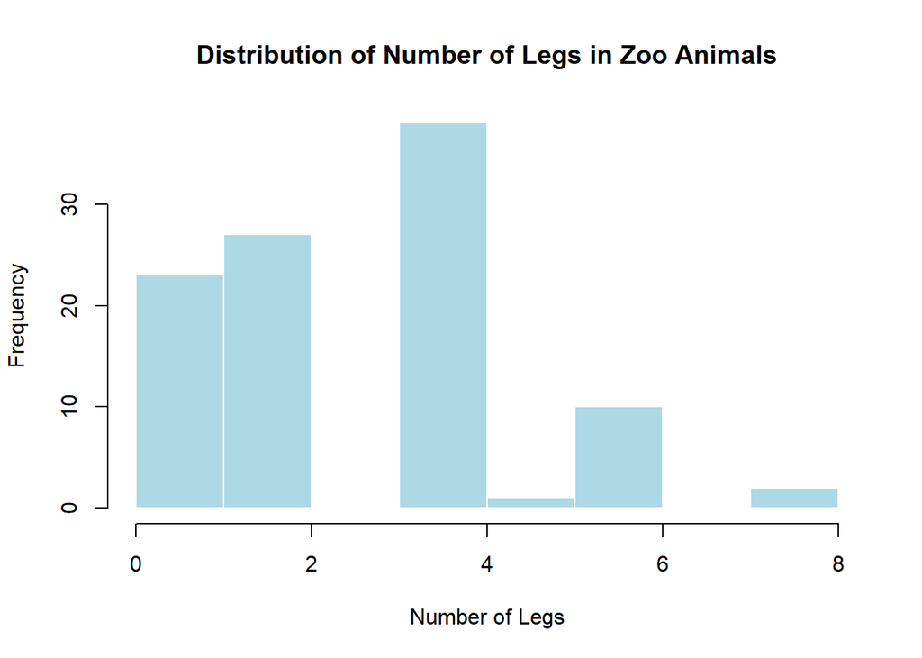

```r
# Histogram of number of legs
hist(zoo_data$legs,
     main = "Distribution of Number of Legs in Zoo Animals",
     xlab = "Number of Legs",
     col = "lightblue",
     border = "white")
```

### 5.2. The Relationship Map (ggplot2 Scatter Plot)

Now, let’s look for patterns using the industry-standard package, **ggplot2**.

1. Choose **two numeric variables** to see if they are correlated.
2. Create a scatter plot using `geom_point()`.
3. Add `geom_smooth()` to add a relationship between variables to the plot.
4. Add `labs()` to rename your axes and title.

```
Ignoring unknown labels:
• colour : "Legend"
```

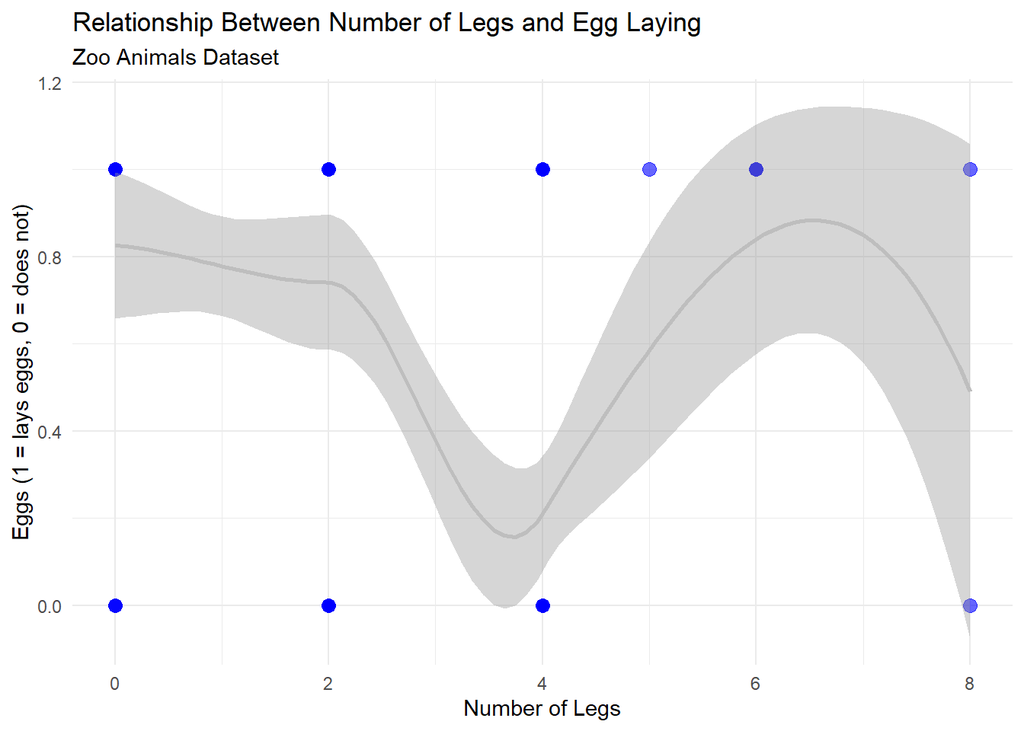

```r
library(ggplot2)
ggplot(data = zoo_data, aes(x = legs, y = eggs)) +
  geom_point(alpha = 0.6, size = 3, colour = "blue") +
  geom_smooth(colour = "gray") +
  labs(
    title = "Relationship Between Number of Legs and Egg Laying",
    subtitle = "Zoo Animals Dataset",
    x = "Number of Legs",
    y = "Eggs (1 = lays eggs, 0 = does not)",
    color = "Legend"
  ) +
  theme_minimal()
```

### 5.3. The Comparison (ggplot2 Boxplot)

3. The Comparison (ggplot2 Boxplot)

Boxplots are excellent for comparing groups. Let’s see how different categories in your universe perform.

1. Choose a **categorical (or logical) variable** for the X-axis (e.g., city, planet_type, species).
2. Choose a **numeric variable** for the Y-axis (e.g., price, gravity, lifespan).
3. Create a plot using `geom_boxplot()`.
4. **Bonus:** Use `fill` to colour the boxes by the same category.

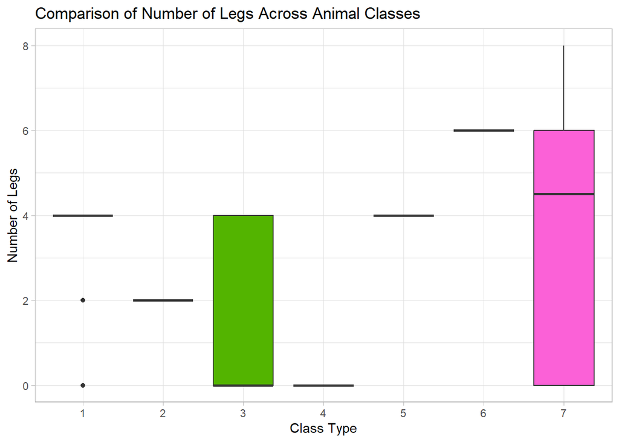

```r
ggplot(data = zoo_data, aes(x = factor(class_type), y = legs, fill = factor(class_type))) +
  geom_boxplot() +
  labs(
    title = "Comparison of Number of Legs Across Animal Classes",
    x = "Class Type",
    y = "Number of Legs"
  ) +
  theme_light() +
  theme(legend.position = "none")
```

### 5.4. The “Deep Dive” (Faceting or Custom)

The most powerful feature of `ggplot2` is faceting—creating small multiples of the same plot for different groups.

1. Create a plot (histogram, bar plot, or scatter plot).
2. Use `facet_wrap(~ your_category_variable)` to split the plot into a separate panel for each group in your data.
3. This is incredibly useful for comparing distinct groups (e.g., separate charts for each City or Year).

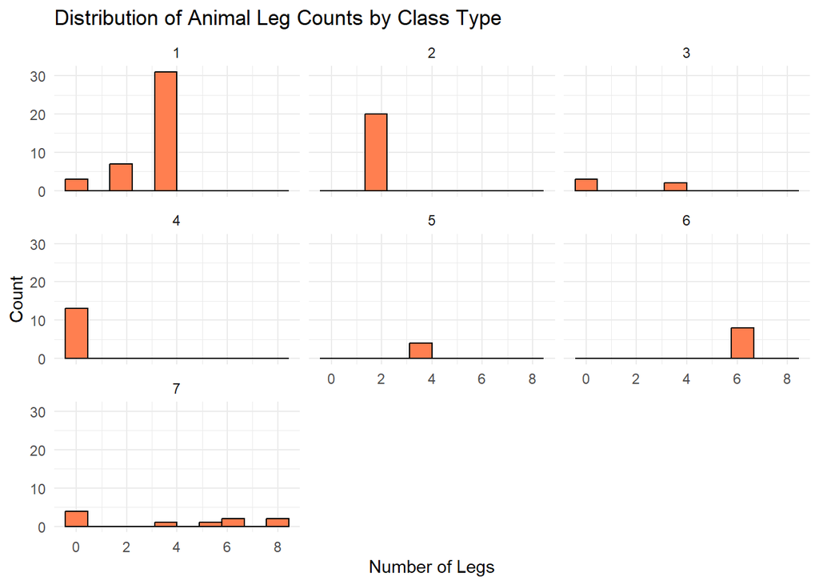

```r
ggplot(data = zoo_data, aes(x = legs)) +
  geom_histogram(bins = 10, fill = "coral", color = "black") +
  facet_wrap(~ class_type) +
  labs(
    title = "Distribution of Animal Leg Counts by Class Type",
    x = "Number of Legs",
    y = "Count"
  ) +
  theme_minimal()
```

### 5.5. Final Step: Exporting (Saving Your Work)

A plot is useless if you can’t put it in a report.

1. Choose your favourite plot from the exercises above.
2. Run the code to display it in R.
3. Immediately run the following command to save it to your project folder:

```r
ggsave("my_universe_plot.png", width = 8, height = 6)
```